# Rossmann Store Sales

Tom Hettinger

January 31, 2016

# Description

The goal if this project is to explore a data set containing past sales and store information from Rossmann stores, and generate prediction models to forecast future sales earnings. The project description below and more information can be found on the kaggle website at https://www.kaggle.com/c/rossmann-store-sales.

> Rossmann operates over 3,000 drug stores in 7 European countries. Currently, Rossmann store managers are tasked with predicting their daily sales for up to six weeks in advance. Store sales are influenced by many factors, including promotions, competition, school and state holidays, seasonality, and locality. With thousands of individual managers predicting sales based on their unique circumstances, the accuracy of results can be quite varied.

> In their first Kaggle competition, Rossmann is challenging you to predict 6 weeks of daily sales for 1,115 stores located across Germany. Reliable sales forecasts enable store managers to create effective staff schedules that increase productivity and motivation. By helping Rossmann create a robust prediction model, you will help store managers stay focused on whatâs most important to them: their customers and their teams!

The following packages were used in this project:

```r
require(ggplot2)
require(hexbin)
require(dplyr)
require(memisc)
```

# Data Preprocessing

We begin by reading in the training data, store data, and test data.

```r
set.seed(1337)
store = read.csv("data/store.csv")
train = read.csv("data/train.csv")
#test = read.csv("data/test.csv")
```

### Looking at store.csv

The Store data set contains a description of the 1,115 stores, including parameters such as a store ID (1 through 1115), store type, distance to competitors, and whether stores participated in continuous promotional campaigns.

```r
str(store)
```

```
## 'data.frame':    1115 obs. of  10 variables:
##  $ Store                    : int  1 2 3 4 5 6 7 8 9 10 ...
##  $ StoreType                : Factor w/ 4 levels "a","b","c","d": 3 1 1 3 1 1 1 1 1 1 ...
##  $ Assortment               : Factor w/ 3 levels "a","b","c": 1 1 1 3 1 1 3 1 3 1 ...
##  $ CompetitionDistance      : int  1270 570 14130 620 29910 310 24000 7520 2030 3160 ...
##  $ CompetitionOpenSinceMonth: int  9 11 12 9 4 12 4 10 8 9 ...
##  $ CompetitionOpenSinceYear : int  2008 2007 2006 2009 2015 2013 2013 2014 2000 2009 ...
##  $ Promo2                   : int  0 1 1 0 0 0 0 0 0 0 ...
##  $ Promo2SinceWeek          : int  NA 13 14 NA NA NA NA NA NA NA ...
##  $ Promo2SinceYear          : int  NA 2010 2011 NA NA NA NA NA NA NA ...
##  $ PromoInterval            : Factor w/ 4 levels "","Feb,May,Aug,Nov",..: 1 3 3 1 1 1 1 1 1 1 ...
```

| Field | Description |
| --- | --- |
| Store | unique store ID ranging from 1 to 1115 |
| StoreType | classification of 4 different store models: “a”, “b”, “c”, or “d” |
| Assortment | describes an assortment level: “a”=basic, “b”=extra, or “c”=extended |
| CompetitionDistance | distance in meters to the nearest competitor |
| CompetitionOpenSinceMonth | month in which nearest competitor opened |
| CompetitionOpenSinceYear | year in which nearest competitor opened |
| Promo2 | a continuing and consecutive promotion that a store may (1) or may not (0) be running |
| Promo2SinceWeek | week in which the store began Promo2 |
| Promo2SinceYear | year in which the store began Promo2 |
| PromoInterval | describes the intervals in which Promo2 rounds begin. For example, “Feb,May,Aug,Nov” means that each round starts in the months of February, May, August, and November |

```r
summary(store$StoreType)
```

```
##   a   b   c   d
## 602  17 148 348
```

Most stores are of type “a”, with only a small number of type “b” stores.

```r
summary(store$Assortment)
```

```
##   a   b   c
## 593   9 513
```

Store assortments are either “basic” or “extendend”, with the exception of 9 stores with “extra”" assortment.

```r
summary(store$CompetitionDistance)
```

```
##    Min. 1st Qu.  Median    Mean 3rd Qu.    Max.    NA's
##    20.0   717.5  2325.0  5405.0  6882.0 75860.0       3
```

Competitor stores range from 20 m to over 75 km from the Rossman stores, with a median distance of 2.3 km.

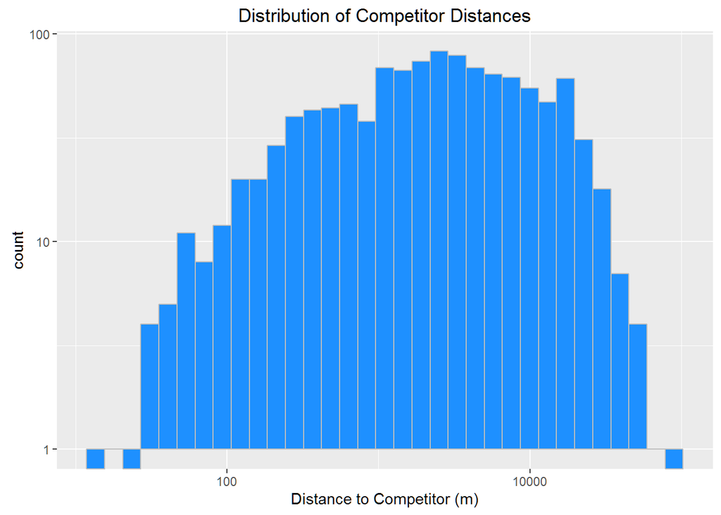

```r
summary(store$CompetitionOpenSinceYear)
```

```
##    Min. 1st Qu.  Median    Mean 3rd Qu.    Max.    NA's
##    1900    2006    2010    2009    2013    2015     354
```

```r
head(sort(store$CompetitionOpenSinceYear))
```

```
## [1] 1900 1961 1990 1990 1990 1990
```

All but 2 (excluding NA) competitor stores opened in, or after, 1990. Ignoring the the two stores from 1900 and 1961:

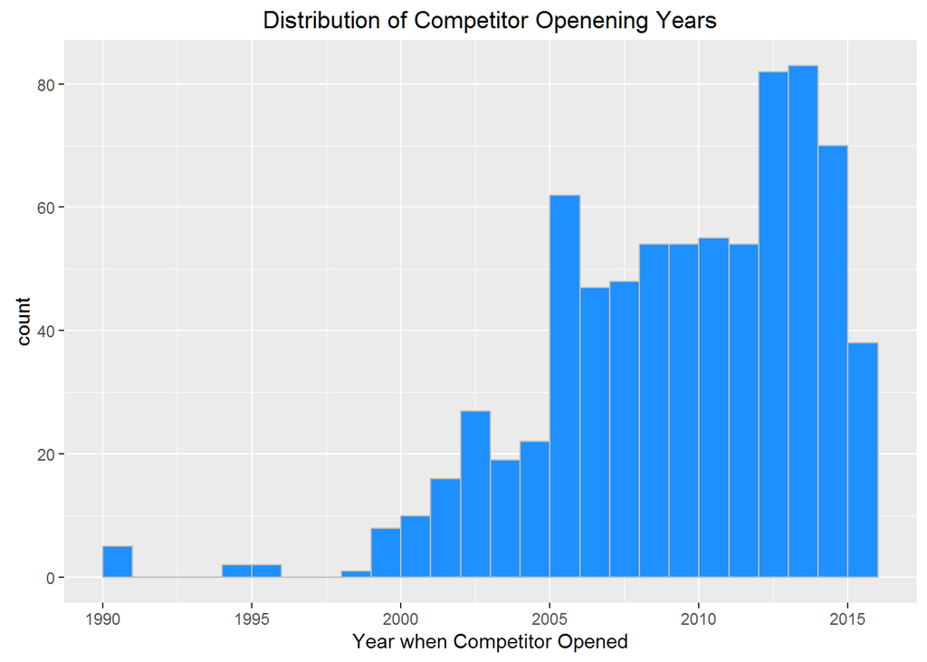

```r
summary(factor(store$Promo2))
```

```
##   0   1
## 544 571
```

```r
summary(store$Promo2SinceYear)
```

```
##    Min. 1st Qu.  Median    Mean 3rd Qu.    Max.    NA's
##    2009    2011    2012    2012    2013    2015     544
```

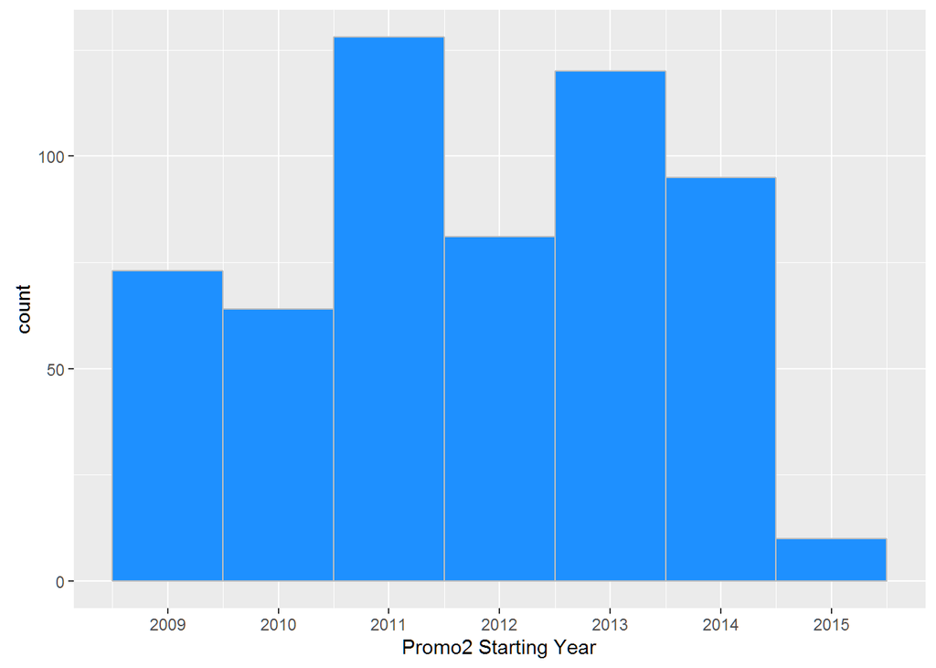

```r
summary(store$PromoInterval)
```

```
##                   Feb,May,Aug,Nov  Jan,Apr,Jul,Oct Mar,Jun,Sept,Dec
##              544              130              335              106
```

About half of the stores run continuous / consecutive promotions. Those that do, have a MODE interval of “Jan,Apr,Jul,Oct”.

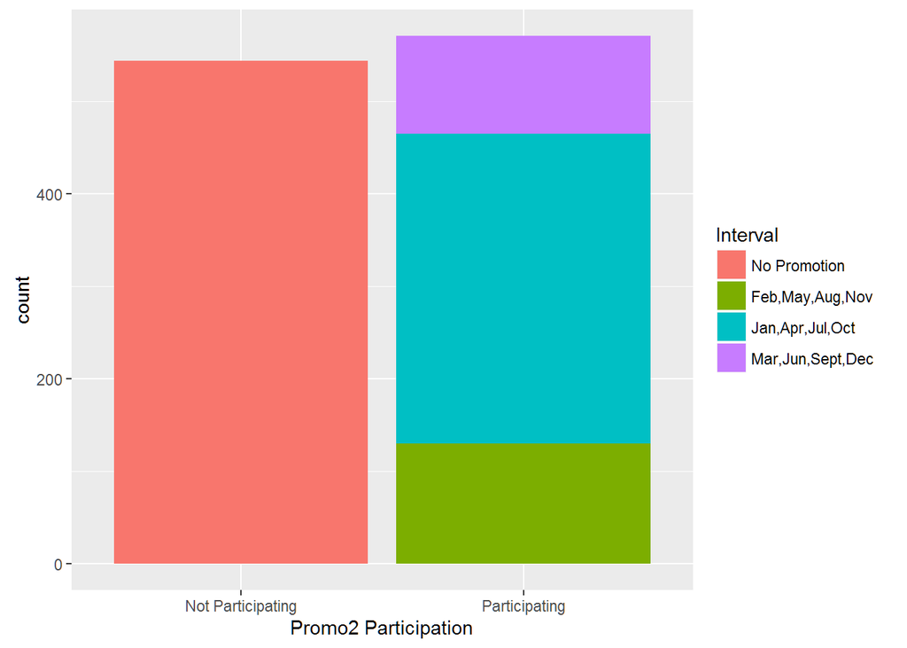

### Looking at train.csv

The training data set contains a sales information from stores on various days.

```r
str(train)
```

```
## 'data.frame':    1017209 obs. of  9 variables:
##  $ Store        : int  1 2 3 4 5 6 7 8 9 10 ...
##  $ DayOfWeek    : int  5 5 5 5 5 5 5 5 5 5 ...
##  $ Date         : Factor w/ 942 levels "2013-01-01","2013-01-02",..: 942 942 942 942 942 942 942 942 942 942 ...
##  $ Sales        : int  5263 6064 8314 13995 4822 5651 15344 8492 8565 7185 ...
##  $ Customers    : int  555 625 821 1498 559 589 1414 833 687 681 ...
##  $ Open         : int  1 1 1 1 1 1 1 1 1 1 ...
##  $ Promo        : int  1 1 1 1 1 1 1 1 1 1 ...
##  $ StateHoliday : Factor w/ 4 levels "0","a","b","c": 1 1 1 1 1 1 1 1 1 1 ...
##  $ SchoolHoliday: int  1 1 1 1 1 1 1 1 1 1 ...
```

| Field | Description |
| --- | --- |
| Store | store ID number |
| DayOfWeek | the day of the week (1-7) (Monday - Sunday) |
| Date | date of information |
| Sales | the turnover for this day in this store (what we are trying to predict) |
| Customers | number of customers in any given day (something we could also predict if we wanted) |
| Open | whether the store was open (1) or closed (0) |
| Promo | whether a store is running a promotion this day (not sure if this is related to Promo2) |
| StateHoliday | indicates a state holiday (usually stores are closed). “a”=public holiday, “b”=Easter, “c”=Christmas“, 0=None” |
| SchoolHoliday | whether (1) or not (0) a store is affected by closure of public schools |

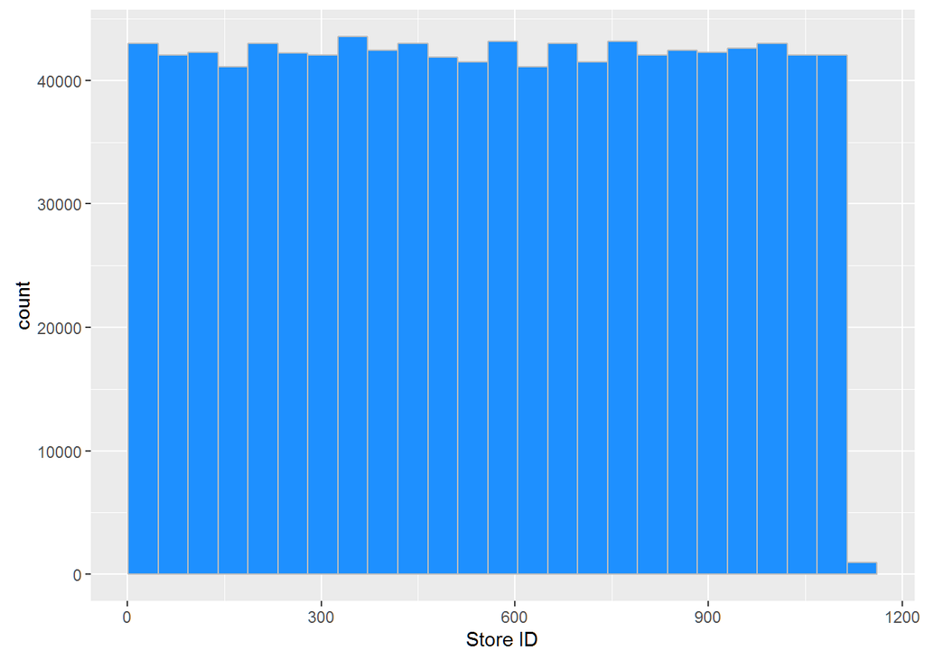

The 1,115 stores appear to be sampled uniformly, as does the day of week for the most part:

```r
summary(factor(train$DayOfWeek))
```

```
##      1      2      3      4      5      6      7
## 144730 145664 145665 145845 145845 144730 144730
```

```r
summary(as.Date(train$Date))
```

```
##         Min.      1st Qu.       Median         Mean      3rd Qu.
## "2013-01-01" "2013-08-17" "2014-04-02" "2014-04-11" "2014-12-12"
##         Max.
## "2015-07-31"
```

```r
length(unique(train$Date))
```

```
## [1] 942
```

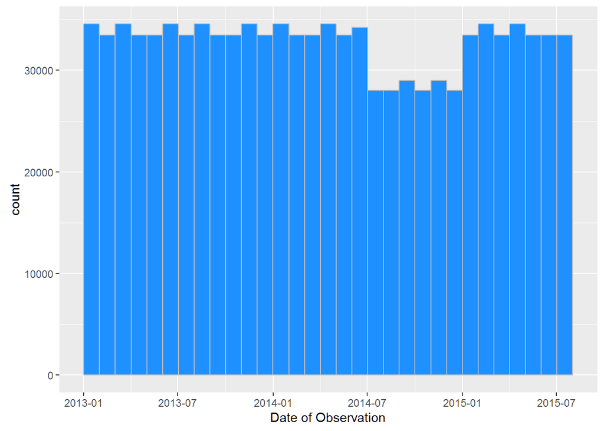

```r
summary(train$Sales)
```

```
##    Min. 1st Qu.  Median    Mean 3rd Qu.    Max.
##       0    3727    5744    5774    7856   41550
```

```r
summary(train$Sales[train$Open == 1])
```

```
##    Min. 1st Qu.  Median    Mean 3rd Qu.    Max.
##       0    4859    6369    6956    8360   41550
```

Median sales for an open store was $6369 per day. Sales = $0.00 when store is closed.

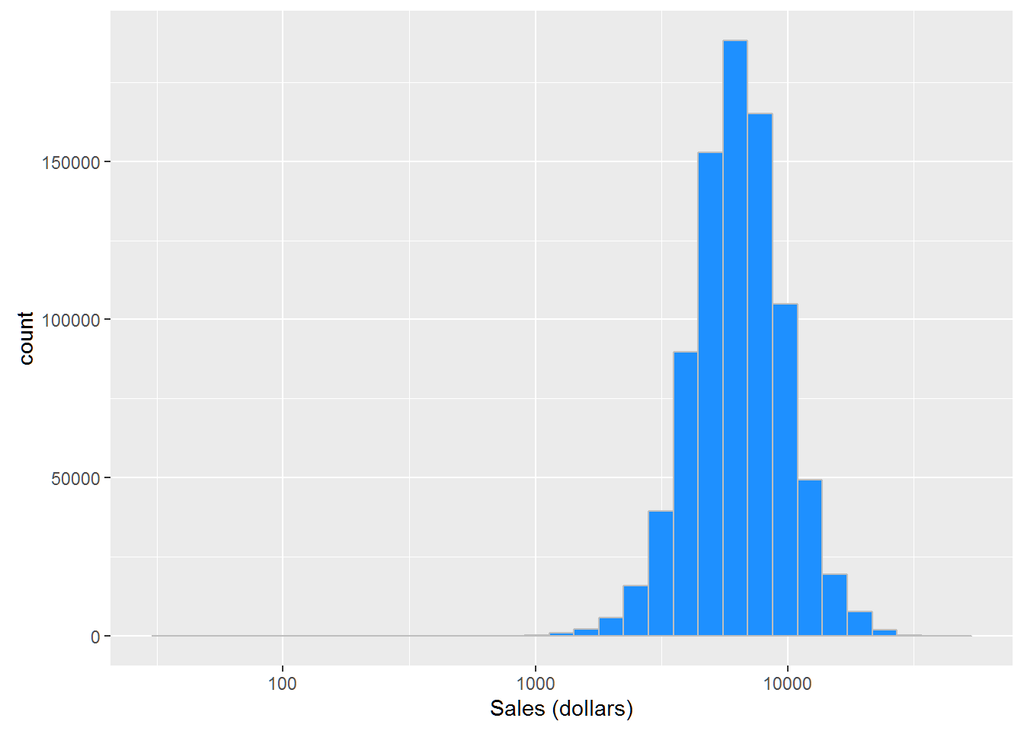

```r
summary(train$Customers)
```

```
##    Min. 1st Qu.  Median    Mean 3rd Qu.    Max.
##     0.0   405.0   609.0   633.1   837.0  7388.0
```

```r
summary(train$Customers[train$Open == 1])
```

```
##    Min. 1st Qu.  Median    Mean 3rd Qu.    Max.
##     0.0   519.0   676.0   762.7   893.0  7388.0
```

Median customer count is 676. Future customer count is uknown, so we cannot use it in our model.

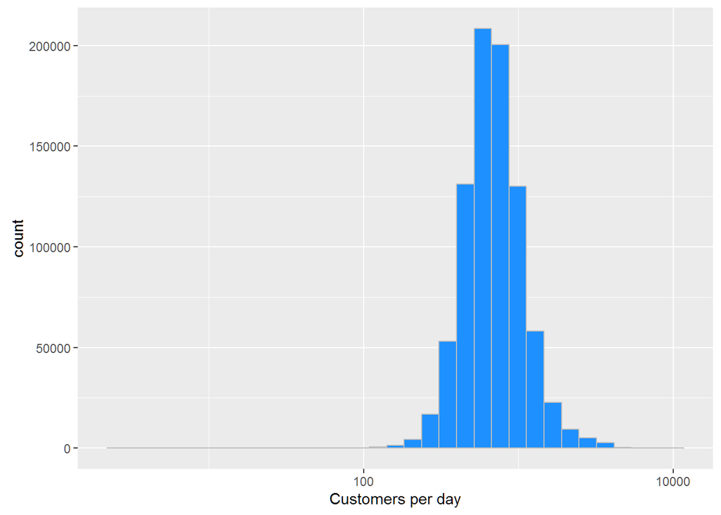

```r
summary(factor(train$Open))
```

```
##      0      1
## 172817 844392
```

```r
1 - (sum(train$Open) / length(train$Open))
```

```
## [1] 0.1698933
```

17% of the data includes days when the store is closed. These will always have $0 in sales, so we do not need to predict these in our model. We should remove them.

```r
summary(factor(train$Promo))
```

```
##      0      1
## 629129 388080
```

```r
summary(factor(train$Promo[train$Open == 1]))
```

```
##      0      1
## 467496 376896
```

Most of the time the store is open, there are no promotions running.

```r
summary(train$StateHoliday)
```

```
##      0      a      b      c
## 986159  20260   6690   4100
```

```r
table(train$StateHoliday, train$Open)
```

```
##
##          0      1
##   0 142677 843482
##   a  19566    694
##   b   6545    145
##   c   4029     71
```

```r
summary(factor(train$SchoolHoliday))
```

```
##      0      1
## 835488 181721
```

```r
table(train$SchoolHoliday, train$Open)
```

```
##
##          0      1
##   0 154553 680935
##   1  18264 163457
```

```r
open_no_holiday = train$Open[train$StateHoliday == 0 & train$SchoolHoliday == 0]
length(open_no_holiday)
```

```
## [1] 819949
```

```r
sum(open_no_holiday)
```

```
## [1] 680339
```

```r
sum(open_no_holiday) / length(open_no_holiday)
```

```
## [1] 0.8297333
```

```r
rm(open_no_holiday)
```

```r
summary(factor(train$DayOfWeek[train$StateHoliday == 0 & train$SchoolHoliday == 0 & train$Open == 0]))
```

```
##      1      2      3      4      5      6      7
##    304    226    209    215    194    274 138188
```

These dates of closure are usually on a Sunday.

```r
table(train$DayOfWeek, train$Open)
```

```
##
##          0      1
##   1   7170 137560
##   2   1703 143961
##   3   3729 141936
##   4  11201 134644
##   5   7205 138640
##   6    672 144058
##   7 141137   3593
```

```r
length(unique(train$Store[train$DayOfWeek == 7 & train$Open == 1]))
```

```
## [1] 33
```

```r
length(unique(train$Date[train$DayOfWeek == 7 & train$Open == 1]))
```

```
## [1] 134
```

Rossman stores almost never open on Sundays.

### Fixing data types and imputing values

First we do a left join of the training set with the store dataframe on store ID, so that we have store information for every observation.

```r
clean = train
clean = merge(clean, store, by="Store", all.x=TRUE)
```

We should transform competitor distance by taking the log since the distances span a large range.

```r
clean$LogCompetitionDistance = log10(clean$CompetitionDistance)
```

We can extrate the Month and Day-of-Month from the original date, and set them as categorical factors. We will use the Year as a continuous variable.

```r
clean$Date.DayOfMonth = factor(format(as.Date(train$Date, "%Y-%m-%d"), "%d"))
clean$Date.Month = factor(format(as.Date(train$Date, "%Y-%m-%d"), "%m"))
clean$Date.Year = as.numeric(format(as.Date(train$Date, "%Y-%m-%d"), "%Y"))
clean$DayOfWeek = factor(train$DayOfWeek)
clean$Date = as.Date(clean$Date)
```

Lets transform the year that the nearest competitor opened, to the number of days that the competitor as been around, so that our model isn’t time dependent.

```r
clean$CompetitionOpenDate = as.Date(paste(clean$CompetitionOpenSinceYear, clean$CompetitionOpenSinceMonth, "01", sep="-"))
clean$CompetitionTenure = clean$Date - clean$CompetitionOpenDate
clean$CompetitionTenure = as.numeric(clean$CompetitionTenure, units = "days")
summary(clean$CompetitionTenure)
```

```
##    Min. 1st Qu.  Median    Mean 3rd Qu.    Max.    NA's
##    -942     448    1558    1851    2877   42210  323348
```

Some observations include points from before the competitor opened up (negative Tenure). We’ll handle this in a bit.

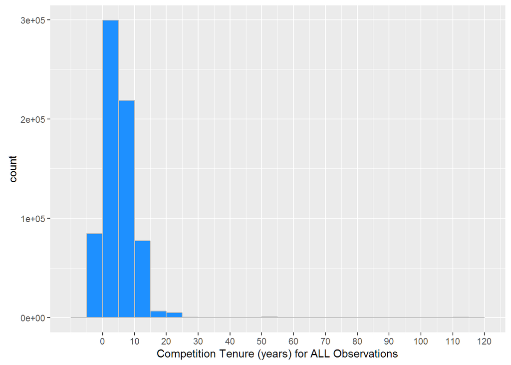

We can similarly transform Promo2Since Week and Year into a Promo2Tenure feature that says how long the Promo2 has been going on for.

```r
clean$Promo2StartDate = as.numeric(as.Date(paste(clean$Promo2SinceYear, "01", "01"), format="%Y %m %d"), units="days")
clean$Promo2StartDate = clean$Promo2StartDate + (7 * (clean$Promo2SinceWeek-1))
clean$Promo2Tenure = as.numeric(clean$Date - clean$Promo2StartDate, units="days")
summary(clean$Promo2Tenure)
```

```
##    Min. 1st Qu.  Median    Mean 3rd Qu.    Max.    NA's
##    -884     259     764     761    1275    2192  508031
```

Some observations also have negative Tenure for Promo2.

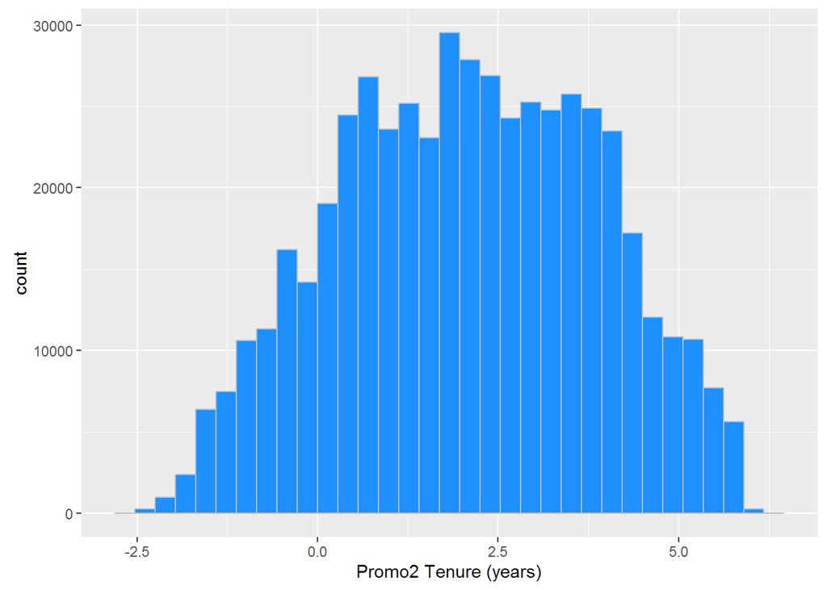

We will also remove the observations for which Open == 0, since we do not care about sales on days the stores were closed.

```r
clean = subset(clean, Open != 0)
clean$Open = NULL
```

StoreID is an important features, since we expect high-grossing stores to have higher sales than smaller stores. Having 1,115 unique levels for a category is computationally intense though. Therefore, we will introduce a new feature, “MedianOfSales”, which contains the median value of all sales for a particular store. This data leak will mean our training set and evaluation scores will be overestimating the true validation scores obtained from the holdout set.

```r
store_medians = summarise(group_by(clean, Store), median(Sales))
names(store_medians)[2] <- "MedianSales"
clean = merge(clean, store_medians, by="Store", all.x=TRUE)

store_means = summarise(group_by(clean, Store), mean(Sales))
names(store_means)[2] <- "MeanSales"
clean = merge(clean, store_means, by="Store", all.x=TRUE)

rm(store_medians)
rm(store_means)
```

We can now remove uncessary Date information. We are removing the Year of observation, since this causes our model to be time-dependent. We want to successfully predict future sales, so we should remove the Year of observation.

```r
clean$CompetitionOpenSinceYear = NULL
clean$CompetitionOpenSinceMonth = NULL
clean$CompetitionOpenDate = NULL
clean$Date = NULL
clean$Date.Year = NULL
clean$Promo2StartDate = NULL
clean$Promo2SinceWeek = NULL
clean$Promo2SinceYear = NULL
```

Which columns have NA values?

```r
colSums(is.na(clean))
```

```
##                  Store              DayOfWeek                  Sales
##                      0                      0                      0
##              Customers                  Promo           StateHoliday
##                      0                      0                      0
##          SchoolHoliday              StoreType             Assortment
##                      0                      0                      0
##    CompetitionDistance                 Promo2          PromoInterval
##                   2186                      0                      0
## LogCompetitionDistance        Date.DayOfMonth             Date.Month
##                   2186                      0                      0
##      CompetitionTenure           Promo2Tenure            MedianSales
##                 268619                 423307                      0
##              MeanSales
##                      0
```

Competition Distance: Let’s use the median value for imputing.

```r
# Replace NA with median
clean$LogCompetitionDistance[is.na(clean$LogCompetitionDistance)] <- median(clean$LogCompetitionDistance, na.rm=TRUE)
```

Competition Tenure - Let’s use the median value here as well. Additionally, it may be unkown if a competitor is opening in the future, so we should set all negative values to the median (negative values excluded). We’ll also introduce a feature “competitionOpened” and set to False where the tenure is negative.

```r
# Create feature describing if a competitor is known to be opened.
clean$CompetitionOpened <- clean$CompetitionTenure >= 0
clean$CompetitionOpened[is.na(clean$CompetitionOpened)] <- FALSE
# Replace negative Tenures with NA
clean$CompetitionTenure[clean$CompetitionTenure < 0] <- NA
# Replace all NAs with median
clean$CompetitionTenure[is.na(clean$CompetitionTenure)] <- median(clean$CompetitionTenure, na.rm=TRUE)
```

Promo2Tenure - Same logic from competition tenure applies to promo2 tenure.

```r
# Create feature describing if promo2 is known to begin
clean$Promo2Begun <- clean$Promo2Tenure >= 0
clean$Promo2Begun[is.na(clean$Promo2Begun)] <- FALSE
# Replace negative with NA
clean$Promo2Tenure[clean$Promo2Tenure < 0] <- NA
# Replace all NA with median
clean$Promo2Tenure[is.na(clean$Promo2Tenure)] <- median(clean$Promo2Tenure, na.rm=TRUE)
```

```r
# Write cleaned data to CSV
write.csv(clean, file="data/clean.csv")
```